# TP Bachelor Etude de la normalité et de la Capabilité du diamètre d’une butée

S. Jaubert

21 décembre 2021

## Traitement des données

Télécharger les données :

```r
donnees<-read.csv2("https://sjaubert.github.io/SPCR/diameter.csv",header = T)
```

Examinons si tout s’est bien passé (le format des données récupérées cause souvent des surprises !) :

```r
is.numeric(donnees$diameter)
```

```
## [1] TRUE
```

Par souci de simplicité, appelons diameter_butee notre vecteur de données :

```r
diameter_butee<-donnees$diameter
```

Petit aperçu de ces 30 premiers relevés (6X5)

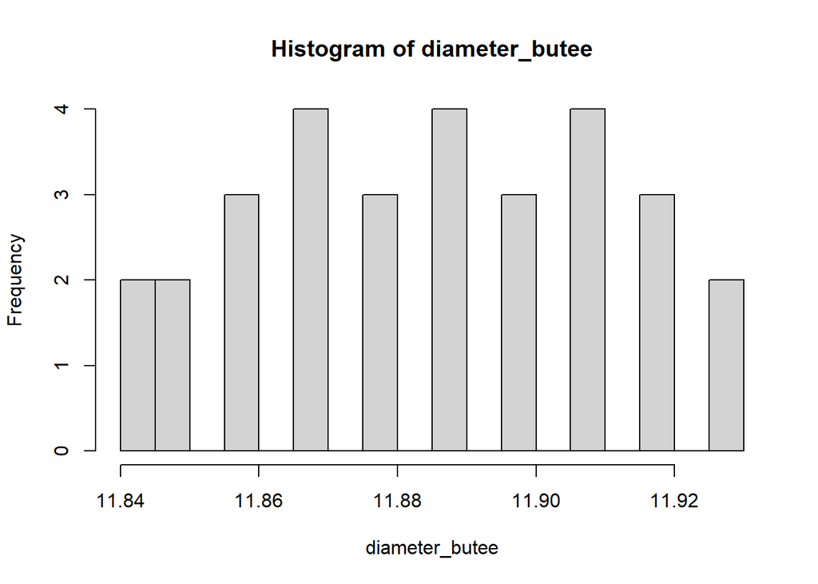

```r
hist(diameter_butee,breaks = 30)
```

Entrons manuellement les 4 échantillons suivants :

```r
dd<-c(11.91,11.95,11.9,11.94,11.93,11.95,11.92,11.95,11.93,11.94,11.95,11.93,11.95,11.95,11.95,11.98,11.94,11.97,11.95,11.95)
```

Puis on concatène les données :

```r
diameter<-c(diameter_butee,dd)
```

## Notre première carte de contrôle

Chargeons la librairie qcc

```r
library(qcc) #chargement de la librairie QCC
```

Regroupons nos données en 10 échantillons de 5 valeurs :

```r
mydata<-qcc.groups(diameter,rep(1:10,each=5))
mydata
```

```
##     [,1]  [,2]  [,3]  [,4]  [,5]
## 1  11.87 11.86 11.84 11.88 11.87
## 2  11.87 11.85 11.86 11.84 11.89
## 3  11.91 11.90 11.86 11.88 11.87
## 4  11.89 11.91 11.89 11.88 11.92
## 5  11.91 11.92 11.93 11.89 11.90
## 6  11.85 11.91 11.92 11.93 11.90
## 7  11.91 11.95 11.90 11.94 11.93
## 8  11.95 11.92 11.95 11.93 11.94
## 9  11.95 11.93 11.95 11.95 11.95
## 10 11.98 11.94 11.97 11.95 11.95
```

Pour des infos supplémentaires sur le package QCC : https://cran.r-project.org/web/packages/qcc/vignettes/qcc_a_quick_tour.html

Faisons notre première carte de contrôle celle des Xbar :

```r
q1<-qcc(data = mydata,type = "xbar")
```

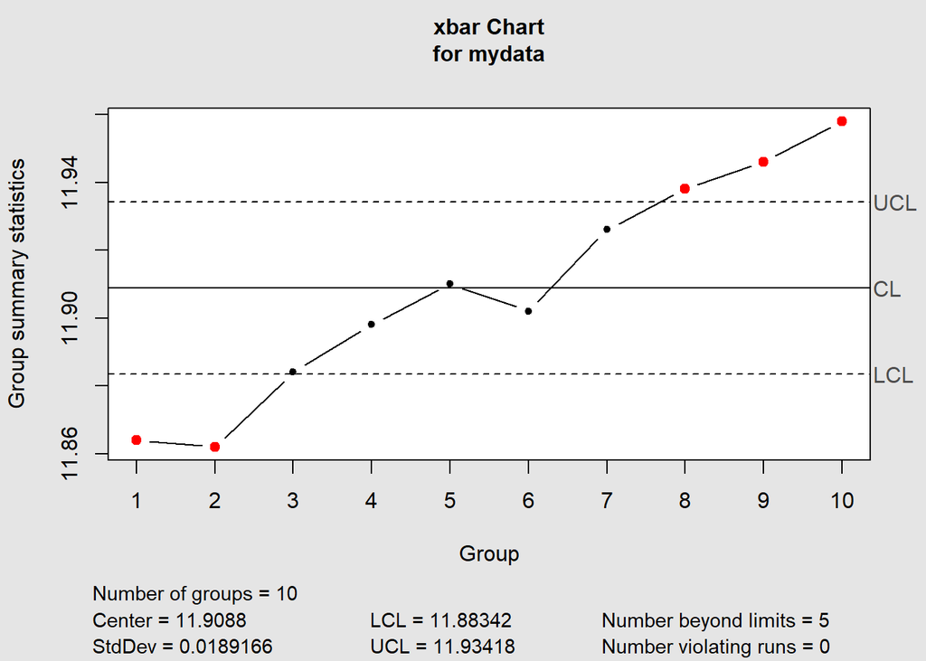

## Calculs des principaux résultats obtenus

Calcul de la moyenne de chaque échantillon puis la moyenne des moyennes :

```r
(x_bar<-apply(mydata,1,mean))
```

```
##      1      2      3      4      5      6      7      8      9     10
## 11.864 11.862 11.884 11.898 11.910 11.902 11.926 11.938 11.946 11.958
```

```r
(x_barbar<-mean(x_bar))
```

```
## [1] 11.9088
```

Calcul de la moyenne des étendues :

```r
x_min<-apply(mydata,1,min)
x_max<-apply(mydata,1,max)
```

La moyenne des étendues est :

```r
(R_bar<-mean(x_max-x_min))
```

```
## [1] 0.044
```

Afin d’estimer l’écart-type en fonction de la moyenne des étendues, on utilisera la fonction d2

$\hat{\sigma}=\frac{\bar{R}}{d2}$

```r
d2=function(n){2*integrate(function(x){n*x*dnorm(x)*pnorm(x)^(n-1)},-Inf,Inf)$val}
```

[Voir ici pour les explications : https://sjaubert.github.io/SPCR/Estimation.pdf](https://sjaubert.github.io/SPCR/Estimation.pdf?target=_blank)

Les calculs nous permettent de retrouver les LCL et UCL obtenus précédemment :

```r
(LCL<-x_barbar-3*R_bar/(sqrt(5)*d2(5)))
```

```
## [1] 11.88342
```

```r
(UCL<-x_barbar+3*R_bar/(sqrt(5)*d2(5)))
```

```
## [1] 11.93418
```

## Etude en deux phases

Nous pouvons considérer que dans un premier temps le calibrage se fasse sur les 6 premiers échantillons, puis nous intégrons dans un deuxième temps les 4 autres échantillons

```r
q2<-qcc(data = mydata[1:6,],type = "xbar",newdata = mydata[7:10,])
```

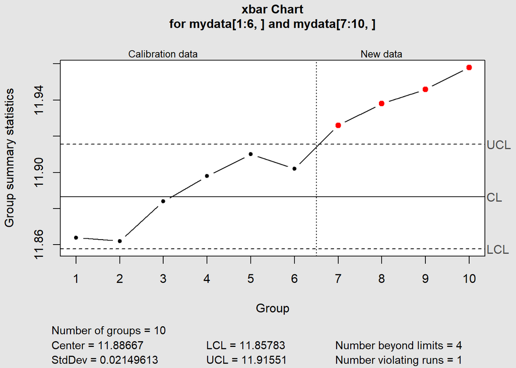

Nous recentrons nos données, nous voyons ainsi que nous aurions pu être alerté beaucoup plus tôt, dès le 7ème échantillon, de cette dérive vers le haut.

## La carte R

```r
q2<-qcc(data = mydata,type="R")
```

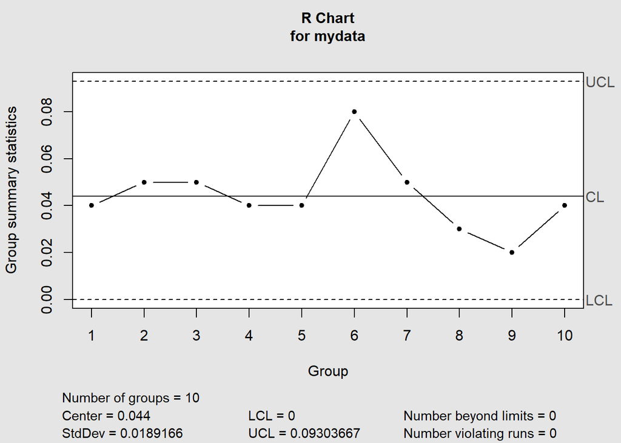

La dispersion semble assez bien maitrisée, pas de différences significatives si on traite en deux phases :

```r
q2<-qcc(data = mydata[1:6,],type="R",newdata = mydata[7:10,])
```

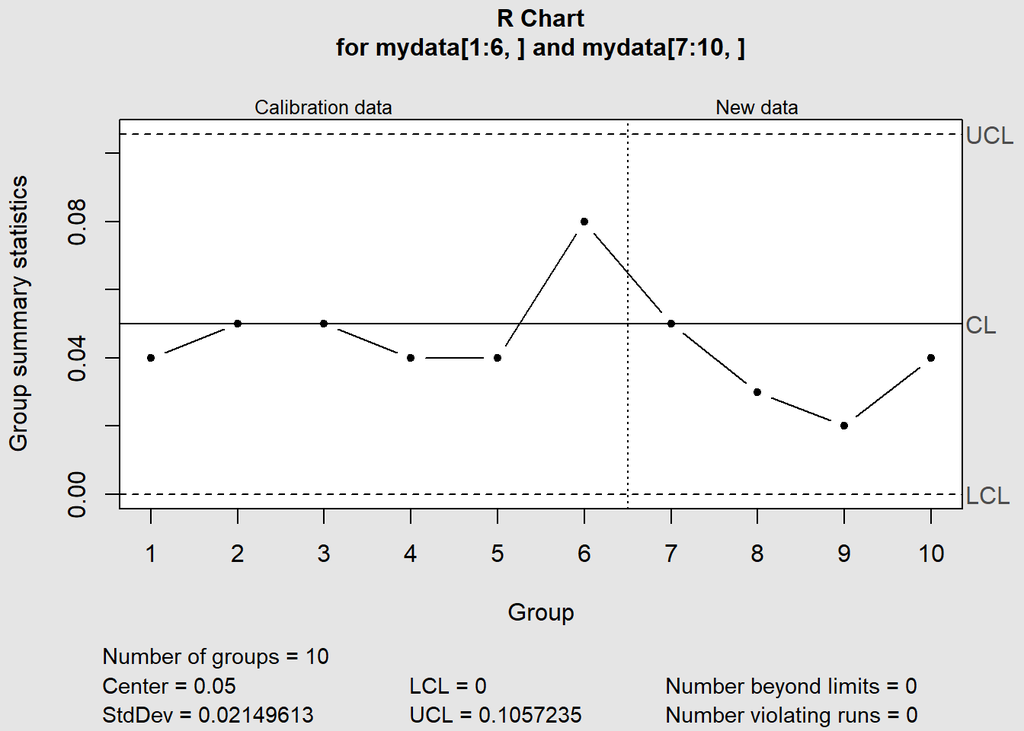

## Etude de normalité

Vérifions si les données sont distribuées normalement

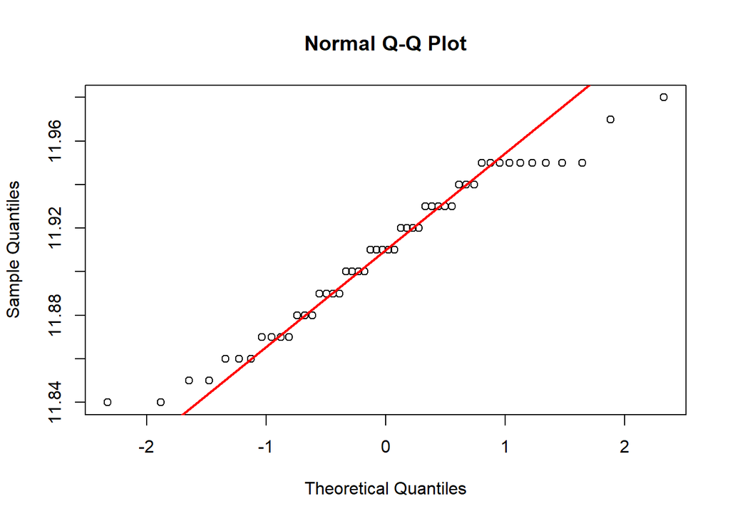

```r
qqnorm(diameter);qqline(diameter,col="red",lwd=2)
```

Un test pour appuyer cette évaluation visuelle est toujours préférable :

```r
shapiro.test(diameter)
```

```
##
##  Shapiro-Wilk normality test
##
## data:  diameter
## W = 0.96175, p-value = 0.1053
```

Avec un p-value > 10% il est raisonnable d’accepter l’hypothèse de normalité ou tout du moins nous ne la rejettons pas…

## Etude la capabilité

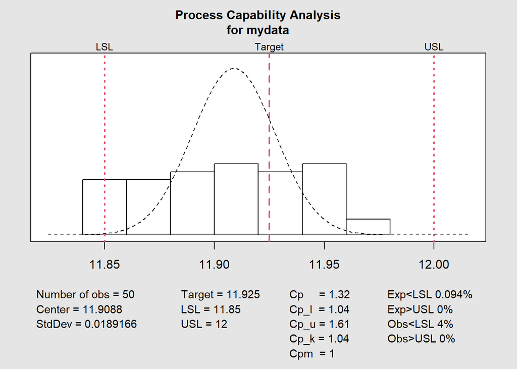

```
##
## Process Capability Analysis
##
## Call:
## process.capability(object = q1, spec.limits = c(11.85, 12), breaks = 10)
##
## Number of obs = 50           Target = 11.93
##        Center = 11.91           LSL = 11.85
##        StdDev = 0.01892         USL = 12
##
## Capability indices:
##
##       Value    2.5%  97.5%
## Cp    1.322  1.0606  1.582
## Cp_l  1.036  0.8473  1.225
## Cp_u  1.607  1.3290  1.885
## Cp_k  1.036  0.8111  1.261
## Cpm   1.004  0.7700  1.237
##
## Exp<LSL 0.094%    Obs<LSL 4%
## Exp>USL 0%    Obs>USL 0%
```

```r
process.capability(q1,spec.limits = c(11.85,12),breaks = 10)
```

Avec un $C_{p}=1.32$ le processus est acceptable le $C_{pk}=1.04$ est par contre trop limite, un décentrage se fait sentir.

Pour l’écart-type :

```r
(sigma<-R_bar/d2(5))
```

```
## [1] 0.01891717
```

Pour une carte S (peu d’intérêt ici car par nature très semblable à une carte R):

```r
q2<-qcc(data = mydata,type="S")
```

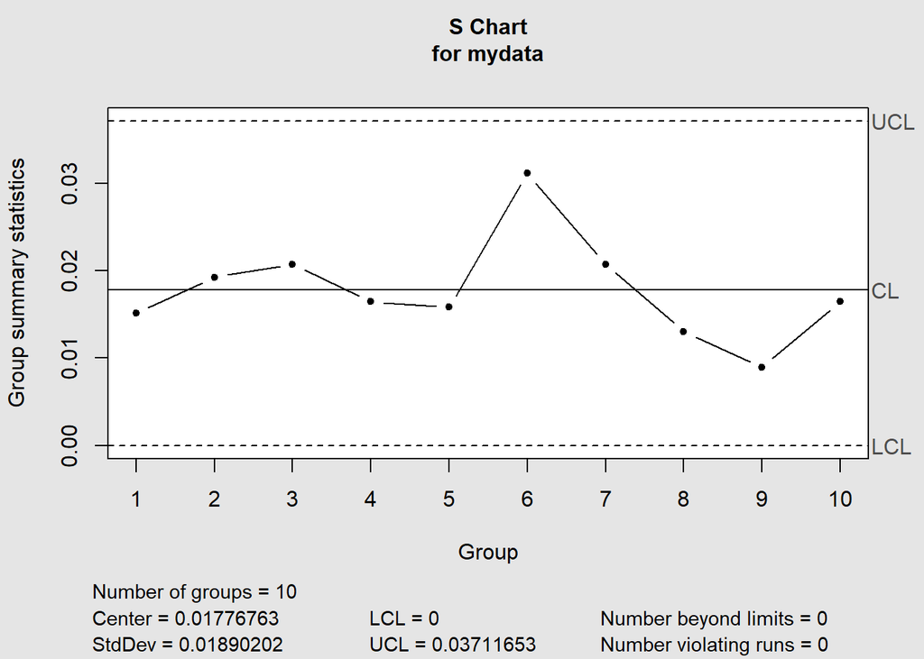